# Statistical inference

In this activity you will repeat the two types of resampling-based inference that are covered in the videos:

1. permutation tests
2. bootstrap samples

but using the all the *Adelie* penguins in the in the **palmerpenguins** data set.

Begin by loading the required packages

```r
library("ggplot2")
library("withr")
library("infer")
library("dplyr")
library("palmerpenguins")
```

Next we will create a data frame containing just the *Adelie* penguins

```r
adelie <- penguins |>
  filter(species == "Adelie" & !is.na(sex) & !is.na(bill_length_mm))
```

## Sexual dimorphism in *Adelie* penguins

In the following section you will investigate sexual dimorphism in the bill lengths of *Adelie* penguins using the entire data set of *Adelie* penguins.

Sexual dimorphism will be reflected in male *Adeli* penguins in the data set being drawn from a population of similar male *Adelie* penguins with a mean bill length that is different to that of the population of female *Adelie* penguins.

Hence our null hypothesis will be that

> male and female *Adelie* penguins are drawn from populations with the *same* (*equal*) average bill length

Mathematically we would write this as

$$\text{H}_0: \mu_{\text{male}} = \mu_{\text{female}}$$

Our **alternative** hypothesis is that

> male and female *Adelie* penguins are drawn from populations with different verage bill lengths

which we would write mathematically as

$$\text{H}_{\text{a}}: \mu_{\text{male}} \neq \mu_{\text{female}}\:.$$

We can reformulate these hypotheses in terms of a *difference of means*, with $\text{H}_0$ then being where the difference of means between the two sexes is equal to 0 (the means are *not* different), while $text{H}_{\text{a}}$ implies that the difference of means is $\neq 0$:

We will assess these hypotheses using a permutation test and then add a confidence interval on the estimated difference in mean bill length between the two sexes using bootstrap resampling.

### Permutation tests using **infer**

We start with a permutation test. For this we will use tools from the **infer** package that you loaded earlier.

The code needed to generate 1000 permutations of the original data is shown below

```r
adelie_shuffled <- withr::with_seed(2,
  adelie |>
    specify(bill_length_mm ~ sex) |>
    hypothesize(null = "independence") |>
    generate(reps = 1000, type = "permute")
)
```

We use:

- `specify()` to indicate to **infer** which is the response variable and which is the explanatory verariable. Here we are interested in variation in `bill_length_mm` due to `sex` so we specify that `bill_length_mm` is the response variable on the left of the `~` and `sex` is the explanatory variable which goes on the right of `~`,
- `hypothesize()` to indcate that our null hypothesis is one of *independence*, i.e. that there is no relationship between bill length and sex,
- `generate()` to generate the 1000 permutations of the original data.
- `withr::with_seed()` to set the random number generator to a known state.

For each permuted data set we need to compute the

1. mean `bill_length_mm` for the males — $\hat{\mu}_{\text{male}}$
2. mean `bill_length_mm` for the females — $\hat{\mu}_{\text{female}}$
3. the **difference** of these two means: $\hat{\mu}_{\text{male}} - \hat{\mu}_{\text{female}}$

This difference of means will be our test statistic.

To do this we use the `calculate()` function:

```r
adelie_null_distribution <- adelie_shuffled |>
  calculate(stat = "diff in means", order = c("male", "female"))
```

- `"diff in means"` is how we tell **infer** that we want a difference of means test statistic,
- `order` is used to set the order of operations in the difference. We set `male` before `female` so that positive values of the difference will indicate males are larger than females.

The ordering doesn’t matter so long as we are consistent throughout.

What is stored in `adelie_null_distribution` is know as the null distribution of the test statistic, or the *sampling distribution* of the difference of means under the null hypothesis.

We can plot the distribution using

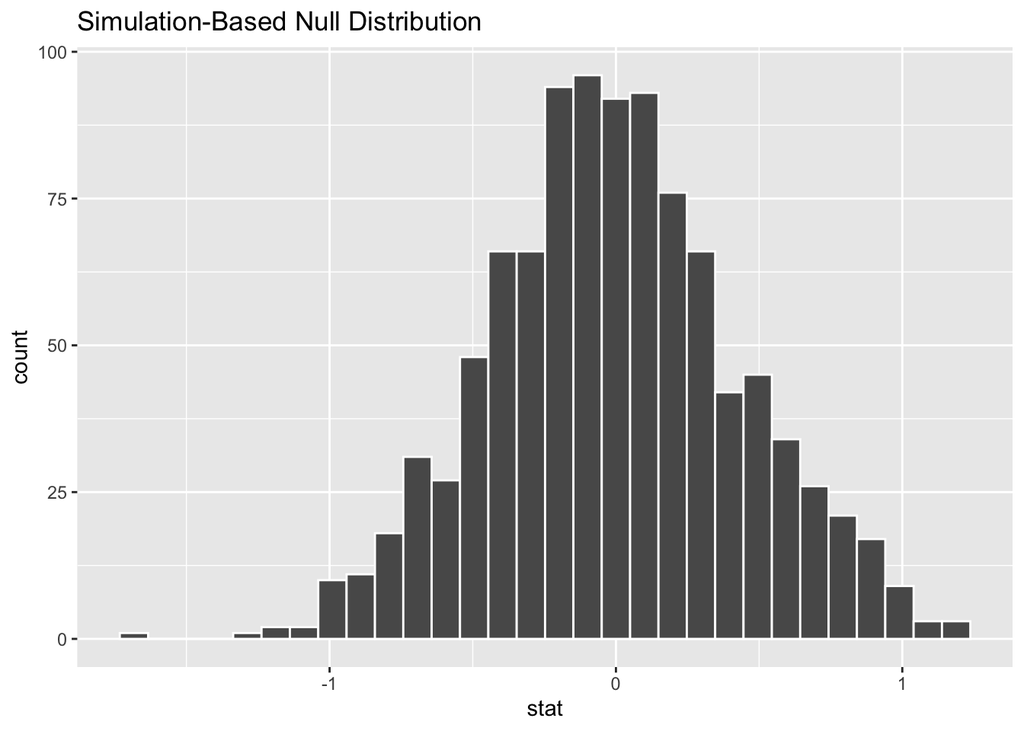

```r
adelie_null_distribution |>
  visualise(bins = 30)
```

**Question**

Describe the shape of the null distribution you generated. What distribution does this resemble?

**Solution**

The null distribution appears roughly bell-shaped, with a peak in the middle and approximate symmetry about this peak.

The distribution that this resembles is a Gaussian or Normal distribution.

We will now compute the observed value of the test statistic using the same pipeline as before, but without the `hypothesize()` and `generate()` steps

```r
obs_diff_means <- adelie |>
  specify(bill_length_mm ~ sex) |>
  calculate(stat = "diff in means", order = c("male", "female"))

obs_diff_means
```

```
Response: bill_length_mm (numeric)
Explanatory: sex (factor)
# A tibble: 1 × 1
   stat
  <dbl>
1  3.13
```

**Question**

What does this number represent? Are male *Adelie* penguins larger on average *in the sample* than females?

**Solution**

In our sample, male *Adelie* penguins are 3.13mm larger than femal *Adelie* penguins.

We can shade the part of the distribution that is as extreme as or more extreme than the observed value of the test statistic

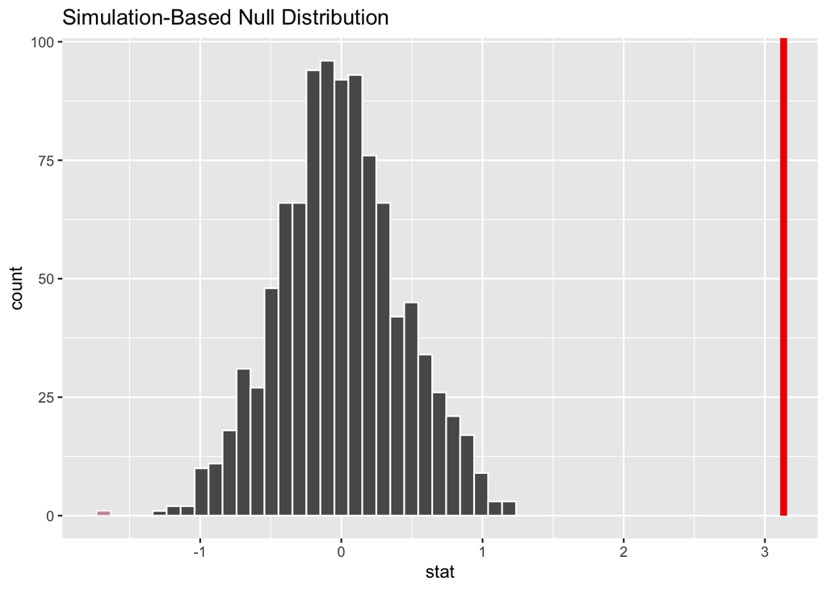

```r
adelie_null_distribution |>
  visualise(bins = 30) +
    shade_p_value(obs_stat = obs_diff_means, direction = "both")
```

This is the *p* value region. We can compute a permutational *p* value using `get_p_value()`

```r
adelie_null_distribution |>
  get_p_value(direction = "two-sided", obs_stat = obs_diff_means)
```

```
# A tibble: 1 × 1
  p_value
    <dbl>
1       0
```

The *p* value returned is equal to 0, which doesn’t make sense as we have at least one test statistic as extreme as the observed one; it is the observed value of the test statistic! Hence we would compute the *p* value in such cases to be

```r
1 / 1001
```

```
[1] 0.000999001
```

## Bootstrap confidence interval

The bootstrap can be used to generate confidence intervals on parameter estimates. A bootstrap sample is one where we draw a data set at ranodm from the observed data that is the same size as the observed data set, but we draw randomly *with replacement*.

For example, to draw a 1000 bootstrap samples for the male *Adelie* penguins and compute the mean bill length for each sample we would use:

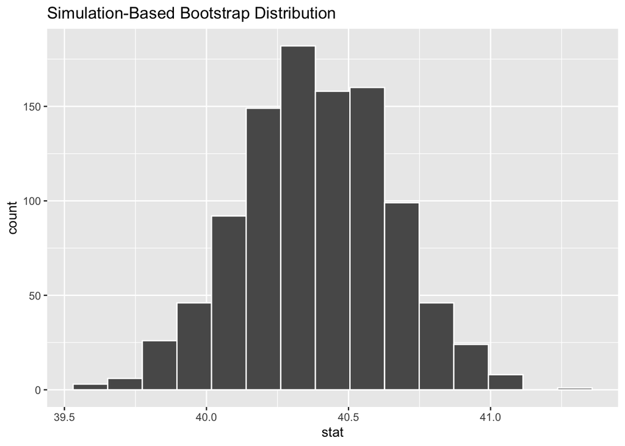

```r
male_boot <- adelie |>
  filter(sex == "male") |>
  specify(response = bill_length_mm) |>
  generate(
    reps = 1000,
    type = "bootstrap") |>
  calculate("mean")

male_boot |>
  visualize()
```

We can compute statistics using the bootstrap distribution. FOr example, the mean and the median of the bootstrap sample are

```r
male_boot |>
  summarise(mean = mean(stat), median = median(stat))
```

```
# A tibble: 1 × 2
   mean median
  <dbl>  <dbl>
1  40.4   40.4
```

We can generate a confidence interval using the *percentile* method. For a 95% percentile-based conifdence interval we compute the 0.25th and 0.975th quantiles of the bootstrap distribution and the endpoints of the enterval:

```r
male_ci <- male_boot |>
  get_ci(type = "percentile", level = 0.95)
```

We can visuliase this interval using

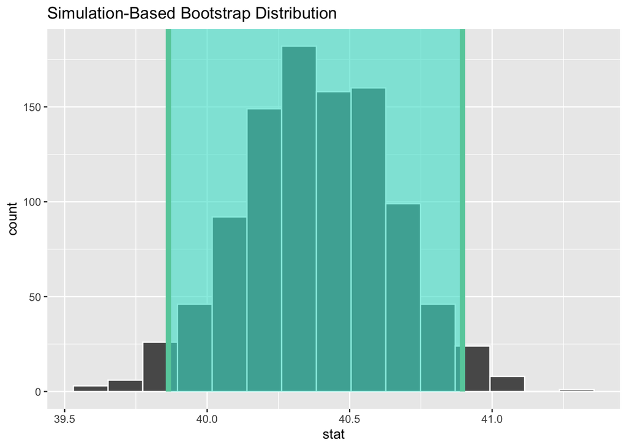

```r
male_boot |>
  visualize() +
  shade_ci(endpoints = male_ci)
```

As far as our main question goes, that of evidence for sexual dimorphism in *Adelie* penguins, we should create a bootstrap sample for the difference of means

```r
boot_distn <- withr::with_seed(42,
  adelie |>
    specify(bill_length_mm ~ sex) |>
    generate(
      reps = 1000,
      type = "bootstrap") |>
    calculate(
      stat = "diff in means",
      order = c("male", "female"))
)
```

The main difference is that now we want the difference of means as the test statistic and we set the order as previously set.

We visualise the distribution using

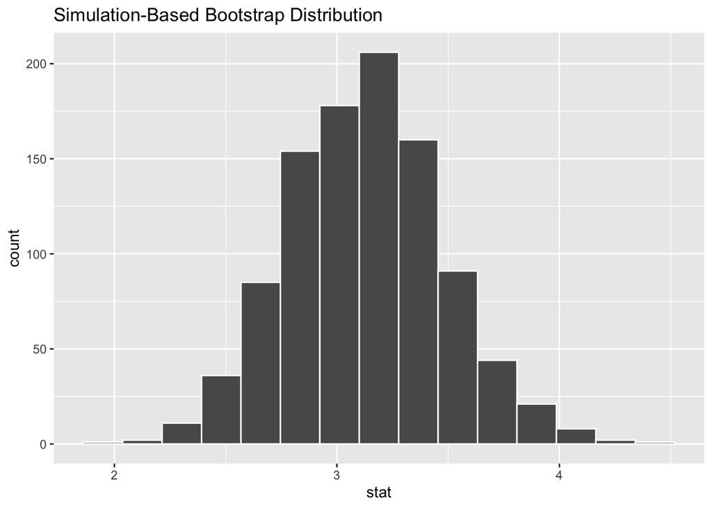

```r
boot_distn |>
  visualize()
```

**Question**

Does the boostrap distribution of the difference of means include 0? What does this tell us about sexual dimorphism in *Adelie* penguins?

**Solution**

No, 0 is not included in the bootstrap distribution of the difference of means. This suggests that male *Adelie* penguins are on average larger than females after accounting for sampling error.

We can compute the confidence interval using the percentile method using

```r
pc_ci <- boot_distn |>
  get_ci(type = "percentile", level = 0.95)

pc_ci
```

```
# A tibble: 1 × 2
  lower_ci upper_ci
     <dbl>    <dbl>
1     2.47     3.88
```

**Question**

Repeat this analysis for the *Chinstrap* penguins. Is there evidence of sexual dimorphism in *Chinstrap* penguin bill lengths?

**Question**

Using the same ideas, instead of comparing males and females of the same species of penguin, test the hypothesis that the flipper length of *Chinstrap* and *Gentoo* penguins are drawn from populations with the same mean length. For this exercise choose one sex, either male or female penguins from both species.

Test your hypothesis with a permutation test and use the bootstrap to create a confidence on the difference of mean flipper lengths for your chosen sex of pengguin.